# Final assignment

Maheswary Muniandy maheswary.muniandy@helsinki.fi

7 March 2017

## Abstract

I used metabolite and clinical data for 80 individuals in order to examine if there are clusters in the metabolite profile. I then analysed whether these groups associated with certain clinical parameters. I used k-means clustering for the cluster analysis and LDA for the discriminate analysis. I found three groups with regards to metabolite profiles and different clinical parameters associating with these these groups i.e. hdl, fatp, tg for cluster 3, scfat and bmi for cluster 2, iafat for cluster 1.

Results at https://muniandy.github.io/IODS-final/

## Final assignment using my own data

### The research question is:

1. Do individuals fall into groups according to their genome-wide metabolites?
2. Do these groups show differences in clinical measures as well?

### data wrangling script is here

“https://github.com/muniandy/IODS-final/create_metab.R”

### methods used: kmeans clustering and LDA

## Data Variables

```r
# load the data


metab = read.table("metabolites.txt", sep="\t", quote = "", stringsAsFactors = FALSE, header=TRUE)

# explore the dataset
str(metab)
```

```
## 'data.frame':    80 obs. of  109 variables:
##  $ ID       : chr  "Pair1-1" "Pair1-2" "Pair2-1" "Pair2-2" ...
##  $ batch    : int  8 8 7 7 7 7 8 8 8 8 ...
##  $ family   : int  100376 100376 100988 100988 101388 101388 101562 101562 104249 104249 ...
##  $ sex      : int  2 2 2 2 1 1 2 2 2 2 ...
##  $ age      : num  34.9 34.9 23.7 23.7 33.5 ...
##  $ bmi      : num  26.4 23.1 26.6 22.2 33.5 ...
##  $ Smoking  : int  1 0 0 0 1 0 0 0 0 0 ...
##  $ fatp     : num  42.1 35.3 31.9 27.3 37.2 ...
##  $ liverfat : num  0.69 0.29 4.43 0.57 9.44 ...
##  $ iafat    : num  2214 1222 909 330 5878 ...
##  $ scfat    : num  6405 4546 3717 2611 6965 ...
##  $ kol      : num  4.1 4.1 4.4 3.8 6.2 ...
##  $ hdl      : num  1.27 1.69 1.27 1.94 0.93 ...
##  $ ldl      : num  2.4 2.1 2.7 1.5 3.8 ...
```

[output cut: 86 more lines]

```r
print("Summary before scaling")
```

```
## [1] "Summary before scaling"
```

```r
summary(metab)
```

```
##       ID                batch         family             sex
##  Length:80          Min.   :2.0   Min.   : 100376   Min.   :1.00
##  Class :character   1st Qu.:4.0   1st Qu.: 107717   1st Qu.:1.00
##  Mode  :character   Median :8.0   Median : 116674   Median :2.00
##                     Mean   :6.6   Mean   : 438993   Mean   :1.55
##                     3rd Qu.:8.0   3rd Qu.:1073912   3rd Qu.:2.00
##                     Max.   :9.0   Max.   :1195442   Max.   :2.00
##
##       age             bmi           Smoking           fatp
##  Min.   :22.78   Min.   :19.68   Min.   :0.000   Min.   : 8.90
##  1st Qu.:25.40   1st Qu.:24.12   1st Qu.:0.000   1st Qu.:28.48
##  Median :31.92   Median :26.75   Median :0.000   Median :34.00
##  Mean   :30.73   Mean   :27.88   Mean   :0.275   Mean   :34.16
##  3rd Qu.:33.97   3rd Qu.:30.57   3rd Qu.:1.000   3rd Qu.:41.05
##  Max.   :36.15   Max.   :44.23   Max.   :1.000   Max.   :52.30
##
##     liverfat           iafat            scfat              kol
##  Min.   : 0.1378   Min.   :  95.0   Min.   :  826.8   Min.   :2.700
##  1st Qu.: 0.5104   1st Qu.: 463.9   1st Qu.: 2645.1   1st Qu.:3.900
##  Median : 0.8195   Median : 884.7   Median : 4083.7   Median :4.450
##  Mean   : 2.8682   Mean   :1147.2   Mean   : 4511.3   Mean   :4.511
##  3rd Qu.: 3.5699   3rd Qu.:1488.3   3rd Qu.: 5765.2   3rd Qu.:4.925
##  Max.   :24.2500   Max.   :5878.0   Max.   :15129.0   Max.   :6.900
##
##       hdl             ldl              tg            crp
##  Min.   :0.520   Min.   :0.980   Min.   :0.37   Min.   : 0.140
##  1st Qu.:1.137   1st Qu.:2.300   1st Qu.:0.65   1st Qu.: 0.455
##  Median :1.325   Median :2.700   Median :0.96   Median : 0.970
##  Mean   :1.418   Mean   :2.770   Mean   :1.09   Mean   : 2.456
##  3rd Qu.:1.650   3rd Qu.:3.125   3rd Qu.:1.23   3rd Qu.: 2.595
##  Max.   :2.560   Max.   :5.100   Max.   :4.37   Max.   :26.020
##                                                 NA's   :1
##    HMDB00123       HMDB00925          HMDB00161       HMDB01051
##  Min.   :1.914   Min.   :-0.03145   Min.   :2.236   Min.   :1.561
##  1st Qu.:2.241   1st Qu.: 0.42379   1st Qu.:2.473   1st Qu.:1.777
##  Median :2.382   Median : 0.59592   Median :2.540   Median :1.821
##  Mean   :2.370   Mean   : 0.61455   Mean   :2.530   Mean   :1.816
##  3rd Qu.:2.485   3rd Qu.: 0.79001   3rd Qu.:2.592   3rd Qu.:1.878
##  Max.   :2.741   Max.   : 2.09254   Max.   :2.769   Max.   :2.018
##
```

[output cut: 169 more lines]

```
##  Min.   :-2.1418   Min.   :-1.5561   Min.   :-2.3986   Min.   :-2.978
##  1st Qu.:-1.6150   1st Qu.:-0.9855   1st Qu.:-1.6868   1st Qu.:-2.490
##  Median :-1.5240   Median :-0.8640   Median :-1.4508   Median :-2.240
##  Mean   :-1.4803   Mean   :-0.7804   Mean   :-1.4951   Mean   :-2.272
##  3rd Qu.:-1.3161   3rd Qu.:-0.6493   3rd Qu.:-1.3150   3rd Qu.:-2.074
##  Max.   :-0.7247   Max.   : 0.5073   Max.   :-0.9791   Max.   :-1.507
##
##    HMDB06460
##  Min.   :-2.0630
##  1st Qu.:-1.5196
##  Median :-1.3874
##  Mean   :-1.3878
##  3rd Qu.:-1.2566
##  Max.   :-0.5875
##
```

```r
dim(metab)
```

```
## [1]  80 109
```

The metabolites are highly co-linear.

The individuals themselves are monozygotic twins and thus share the same genotype (gene profile) as his or her co-twin.

There are 80 rows and 109 variables in this dataset.

All variables are numerical/integer except sex, batch and smoking which are factors.

## Relationship and correlation between clinical variables

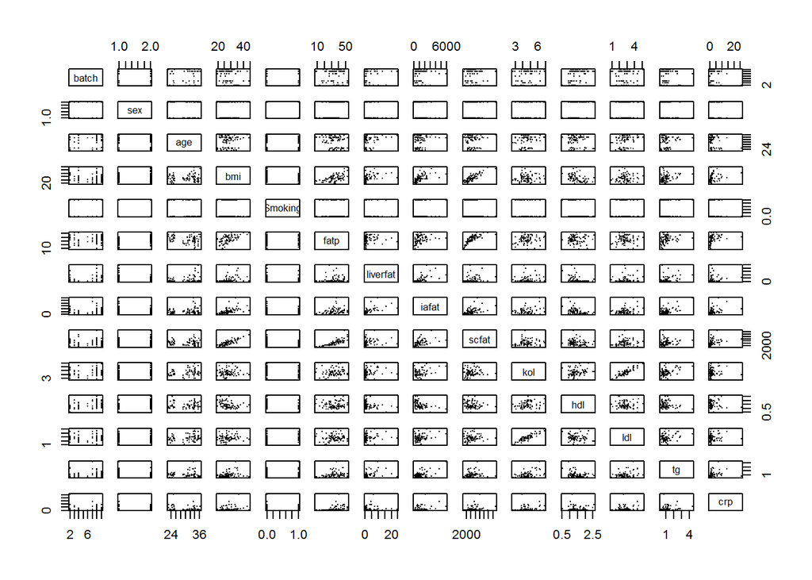

```
##          batch   sex   age   bmi Smoking  fatp liverfat iafat scfat   kol
## batch     1.00  0.18  0.16 -0.30   -0.26  0.00     0.03 -0.06 -0.06  0.16
## sex       0.18  1.00 -0.15 -0.12   -0.12  0.47    -0.33 -0.40  0.21  0.08
## age       0.16 -0.15  1.00  0.05   -0.32 -0.23     0.23  0.20  0.03  0.19
## bmi      -0.30 -0.12  0.05  1.00   -0.01  0.57     0.39  0.55  0.83  0.07
## Smoking  -0.26 -0.12 -0.32 -0.01    1.00 -0.07    -0.11  0.10 -0.16 -0.16
## fatp      0.00  0.47 -0.23  0.57   -0.07  1.00     0.05  0.23  0.79  0.13
## liverfat  0.03 -0.33  0.23  0.39   -0.11  0.05     1.00  0.63  0.25  0.16
## iafat    -0.06 -0.40  0.20  0.55    0.10  0.23     0.63  1.00  0.46  0.27
## scfat    -0.06  0.21  0.03  0.83   -0.16  0.79     0.25  0.46  1.00  0.08
## kol       0.16  0.08  0.19  0.07   -0.16  0.13     0.16  0.27  0.08  1.00
## hdl       0.36  0.43 -0.10 -0.36   -0.36  0.04    -0.30 -0.44 -0.15  0.21
## ldl       0.03 -0.04  0.25  0.11   -0.09  0.04     0.19  0.29  0.08  0.89
## tg       -0.09 -0.17 -0.01  0.29    0.22  0.25     0.35  0.61  0.18  0.48
## crp         NA    NA    NA    NA      NA    NA       NA    NA    NA    NA
##            hdl   ldl    tg crp
## batch     0.36  0.03 -0.09  NA
## sex       0.43 -0.04 -0.17  NA
## age      -0.10  0.25 -0.01  NA
## bmi      -0.36  0.11  0.29  NA
## Smoking  -0.36 -0.09  0.22  NA
## fatp      0.04  0.04  0.25  NA
## liverfat -0.30  0.19  0.35  NA
## iafat    -0.44  0.29  0.61  NA
## scfat    -0.15  0.08  0.18  NA
## kol       0.21  0.89  0.48  NA
## hdl       1.00 -0.10 -0.25  NA
## ldl      -0.10  1.00  0.31  NA
## tg       -0.25  0.31  1.00  NA
## crp         NA    NA    NA   1
```

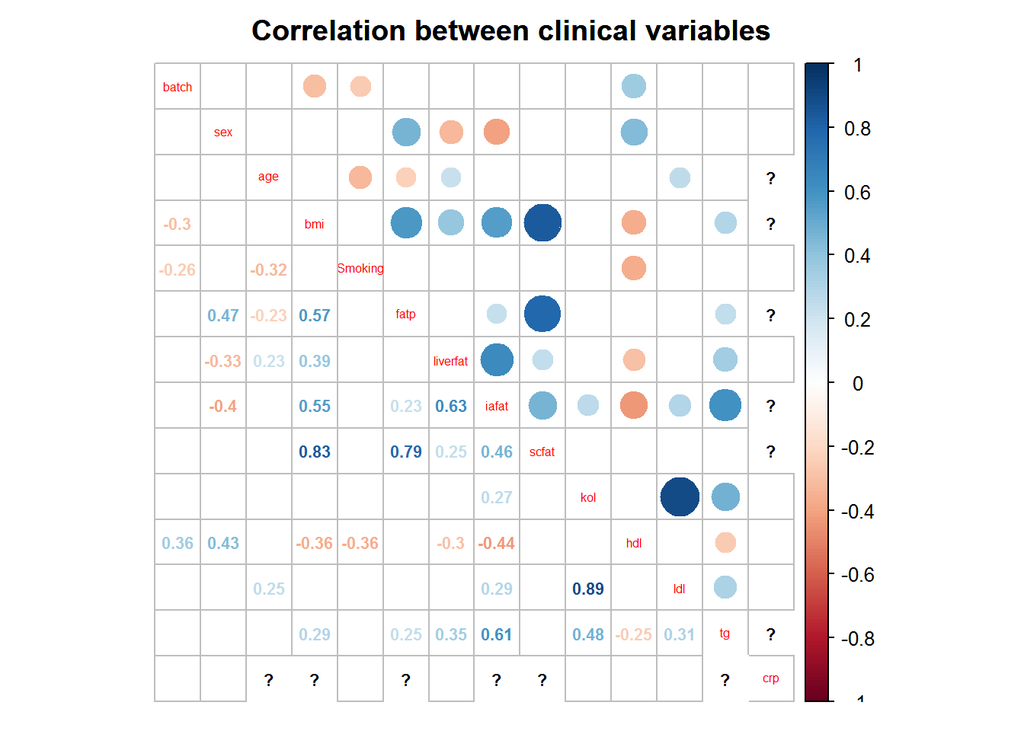

There seems to be a number of linear associations between the variables as shown in the pairplot, eg. between bmi and scfat, bmi and iafat, scfat and fatp, kol and ldl.

High positive correlations: bmi with fatp, iafat and scfat, fatp with scfat, liverfat with iafat, iafat with tg, kol with ldl, iafat with tg.

Here, no correlation value was shown for crp because there was one NA value in there. I am not removing the row because I am interested in other clinical values that have the full dataset.

The table above shows the correlations between the variables. The correlation plot below it shows the value of the above correlations with circles: the bigger the circle, the higher the correlation. Only significant correlations (p-values<0.05) are shown.

## Data Standardization

Summary after scaling of data

```
##      batch              sex               age               bmi
##  Min.   :-1.8835   Min.   :-1.0986   Min.   :-1.8641   Min.   :-1.6197
##  1st Qu.:-1.0646   1st Qu.:-1.0986   1st Qu.:-1.2494   1st Qu.:-0.7424
##  Median : 0.5732   Median : 0.8989   Median : 0.2796   Median :-0.2217
##  Mean   : 0.0000   Mean   : 0.0000   Mean   : 0.0000   Mean   : 0.0000
##  3rd Qu.: 0.5732   3rd Qu.: 0.8989   3rd Qu.: 0.7600   3rd Qu.: 0.5316
##  Max.   : 0.9827   Max.   : 0.8989   Max.   : 1.2721   Max.   : 3.2314
##
##     Smoking            fatp            liverfat           iafat
##  Min.   :-0.612   Min.   :-2.5998   Min.   :-0.6089   Min.   :-1.0373
##  1st Qu.:-0.612   1st Qu.:-0.5852   1st Qu.:-0.5258   1st Qu.:-0.6736
##  Median :-0.612   Median :-0.0166   Median :-0.4569   Median :-0.2588
##  Mean   : 0.000   Mean   : 0.0000   Mean   : 0.0000   Mean   : 0.0000
##  3rd Qu.: 1.614   3rd Qu.: 0.7090   3rd Qu.: 0.1565   3rd Qu.: 0.3363
##  Max.   : 1.614   Max.   : 1.8668   Max.   : 4.7684   Max.   : 4.6640
##
##      scfat              kol                hdl               ldl
##  Min.   :-1.4707   Min.   :-2.08881   Min.   :-2.3126   Min.   :-2.29466
##  1st Qu.:-0.7449   1st Qu.:-0.70492   1st Qu.:-0.7230   1st Qu.:-0.60227
##  Median :-0.1707   Median :-0.07064   Median :-0.2404   Median :-0.08943
##  Mean   : 0.0000   Mean   : 0.00000   Mean   : 0.0000   Mean   : 0.00000
##  3rd Qu.: 0.5005   3rd Qu.: 0.47715   3rd Qu.: 0.5963   3rd Qu.: 0.45547
##  Max.   : 4.2383   Max.   : 2.75481   Max.   : 2.9388   Max.   : 2.98764
##
##        tg               crp
##  Min.   :-1.0584   Min.   :-0.5986
##  1st Qu.:-0.6470   1st Qu.:-0.5172
##  Median :-0.1914   Median :-0.3841
##  Mean   : 0.0000   Mean   : 0.0000
##  3rd Qu.: 0.2054   3rd Qu.: 0.0358
##  Max.   : 4.8197   Max.   : 6.0894
##                    NA's   :1
```

## k-means clustering on metabolite data

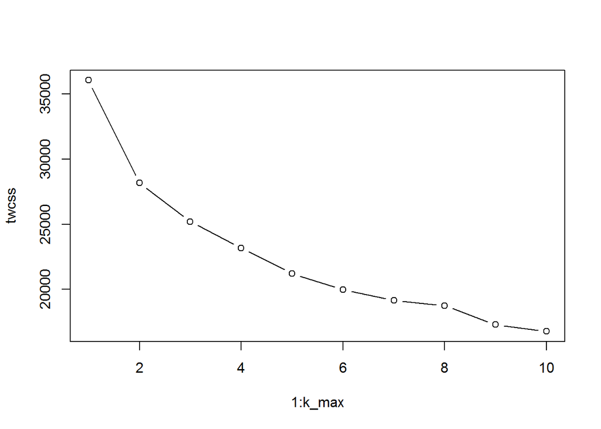

```
##  1  2  3  4  5  6  7  8  9 10 11 12 13 14 15 16 17 18 19 20 21 22 23 24 25
##  2  2  2  2  1  1  2  2  2  2  2  2  1  2  2  1  1  2  1  1  2  1  2  2  1
## 26 27 28 29 30 31 32 33 34 35 36 37 38 39 40 41 42 43 44 45 46 47 48 49 50
##  1  2  2  2  2  2  2  1  2  1  2  1  1  1  1  1  2  2  2  2  2  2  2  1  1
## 51 52 53 54 55 56 57 58 59 60 61 62 63 64 65 66 67 68 69 70 71 72 73 74 75
##  1  1  2  2  1  1  2  2  1  1  1  2  2  2  2  2  2  1  2  2  2  2  1  1  2
## 76 77 78 79 80
##  2  1  2  1  1
```

From the plot, it looks like 3 might be a good number of clusters.

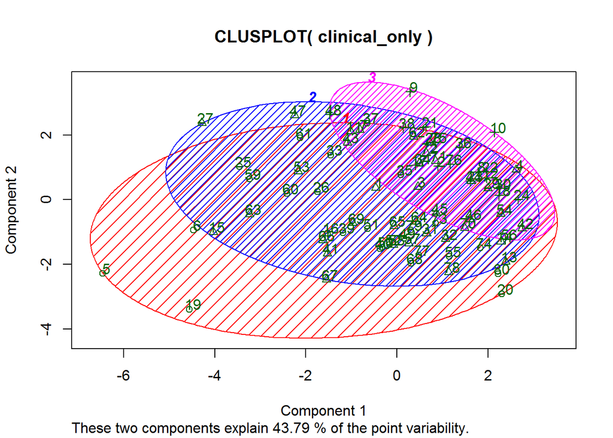

```
##       batch        sex        age        bmi    Smoking       fatp
## 1 0.5732432  0.8988629  0.9875386 -0.2898829  1.6135083  0.8170342
## 2 0.5732432  0.8988629  0.9875386 -0.9478993 -0.6120204  0.1171970
## 3 0.1637838  0.8988629 -1.6482069 -0.2562905 -0.6120204 -0.2327216
## 4 0.1637838  0.8988629 -1.6482069 -1.1198135 -0.6120204 -0.7061409
## 5 0.1637838 -1.0986102  0.6477120  1.1150710  1.6135083  0.3127397
## 6 0.1637838 -1.0986102  0.6477120  0.1566988 -0.6120204  0.2304060
##     liverfat       iafat       scfat        kol        hdl         ldl
## 1 -0.4857617  1.05173519  0.75591514 -0.4742712 -0.3819523 -0.47406007
## 2 -0.5749670  0.07374437  0.01385941 -0.4742712  0.6992269 -0.85869332
## 3  0.3475238 -0.23511147 -0.31721157 -0.1282982 -0.3819523 -0.08942712
## 4 -0.5124229 -0.80557981 -0.75853319 -0.8202440  1.3427858 -1.62795921
## 5  1.4656046  4.66399161  0.97944995  1.9475387 -1.2571923  1.32089378
## 6  0.3260067  3.39418095  0.39386859  1.9475387 -0.9482842  2.09015998
##            tg        crp cluster
## 1 -0.01506250 -0.1515550       2
## 2 -0.17670958  0.9002364       3
## 3  0.29353630 -0.3893064       2
## 4 -0.07384337 -0.3634639       2
## 5  4.81965368  1.1095609       1
## 6  1.99817808  2.9676395       1
```

## LDA Analysis

We now need to split out data into test and training. And we do lda on the train data.

```
## Call:
## lda(as.numeric(cluster) ~ ., data = train)
##
## Prior probabilities of groups:
##      1      2      3
## 0.3125 0.4375 0.2500
##
## Group means:
##        batch         sex        age           bmi    Smoking        fatp
## 1 -0.9008108 -0.49936829 -0.2906067  0.4204981599  0.7232968 -0.08246242
## 2  0.4708784 -0.09987366  0.4105698 -0.0001129157 -0.1351214 -0.08055112
## 3  0.3429223  0.77402085 -0.2855150 -0.6044414045 -0.1947338  0.32817733
##      liverfat       iafat       scfat        kol          hdl         ldl
## 1  0.14639485  0.53218693  0.07536820 -0.1686618 -0.826007882  0.06442604
## 2 -0.06053126 -0.01388071 -0.03914556  0.2011997 -0.001333069  0.21278449
## 3 -0.46405019 -0.61463689 -0.18502071 -0.2724537  0.827938530 -0.52374197
##            tg
## 1  0.44342725
## 2 -0.04970122
## 3 -0.26671763
##
## Coefficients of linear discriminants:
##                 LD1        LD2
## batch     0.5845051 -0.8121994
## sex      -0.2107932  0.3712092
## age       0.5170911 -0.3866187
## bmi      -0.6700487 -0.5372251
## Smoking  -0.1222478 -0.1400295
## fatp      0.7143358  0.5177201
## liverfat  0.2483517  0.0392434
## iafat    -0.5939984  0.2667728
## scfat     0.1285537 -0.3179535
## kol      -0.1839543 -1.8115097
## hdl       0.7721210  0.8962829
## ldl      -0.1348234  1.1030950
## tg        0.1500208  0.8117410
##
## Proportion of trace:
##    LD1    LD2
## 0.7552 0.2448
```

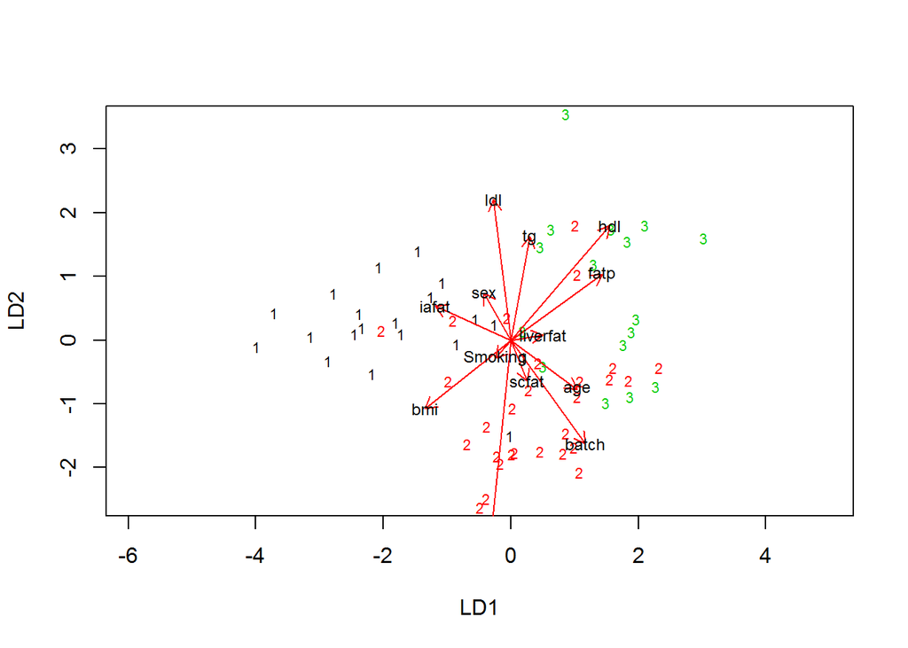

We fit the linear discriminant analysis on the train set. We use the categorical cluster variable as the target variable and all the other variables in the dataset as predictor variables. This gives us an idea how cluster interacts with the other variables.

The biplot shows us which variables are dragging the observations into certain clusters. For instance hdl, fatp, tg are pulling the observation towards cluster 3, scfat and bmi towards cluster 2, iafat towards cluster 1.

We now use the model to predict the cluster classes in the test data.

```
##        predicted
## correct 1 2 3
##       1 3 2 1
##       2 1 6 1
##       3 0 1 1
```

The prediction was highly accurate for the cluster 2 but not so accurate for other clusters.

## Conclusion and discussion

In conclusion, kmeans clustering revealed that there were 3 metabolite profiles. These metabolite profiles then associated nicely with some key clinical measures like scfat, intraabdominal fat, tg and hdl. It might be useful in the future in predicting the molecular patterns just by looking at the clinical measures.

I found that personally for me it is difficult to figure our how many clusters are optimal. And since I deal with twin data (related samples), I’m not sure if I should do anything differently for these methods.